# Inferring interventions from a fitted schedule

From a time-varying transmission rate back to a program, and on to another model

Fitting a model to case data often yields a piecewise-constant transmission rate `β(t)`. `infer` turns the pair (baseline schedule, observed schedule) back into a program: one atom per maximal run where the observed value differs from baseline by a constant ratio (multiplicative algebras) or difference (additive algebras). The program can then be transported to a model with different target names and simulated.

```julia
using CategoricalInterventions
using AlgebraicPetri
using DiffEqCallbacks
using LabelledArrays
using OrdinaryDiffEq
using Plots

default(; linewidth=2, grid=false)
```

## A fitted schedule

We construct one synthetically: a known program is applied to a constant baseline, and the result is rounded as a fit would be.

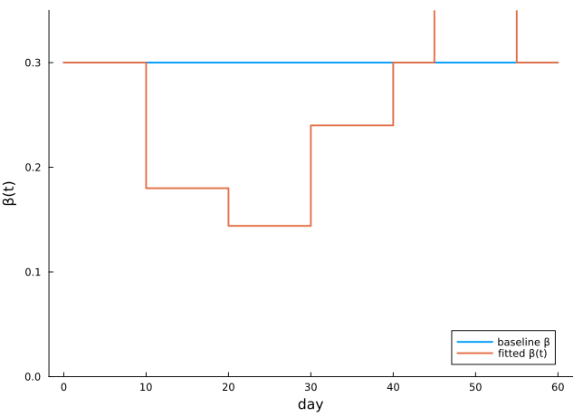

```julia
space = TargetSpace()
declare!(space, :beta, Affine(Multiplicative()); value_type=Float64)

truth = @interventions space begin
    closure = scale(:beta, 0.6; during=10.0..30.0)
    masks   = scale(:beta, 0.8; during=20.0..40.0)
    reopen  = set(:beta, 0.36; during=45.0..55.0)
end

days = collect(0.0:1.0:60.0)
baseline = Dict(:beta => fill(0.30, length(days)))
fitted = Dict(:beta => round.(apply(truth, baseline, days)[:beta]; digits=6))

plot(days, baseline[:beta]; label="baseline β", xlabel="day", ylabel="β(t)", ylims=(0, 0.35))
plot!(days, fitted[:beta]; label="fitted β(t)", seriestype=:steppost)
```

## Infer a program

```julia
inferred = infer(baseline, fitted, days; space=space)
inferred.atoms
```

```
4-element Vector{Atom}:
 beta_1: Parameter:beta scale(0.6) on [10.0, 20.0)
 beta_2: Parameter:beta scale(0.48) on [20.0, 30.0)
 beta_3: Parameter:beta scale(0.8) on [30.0, 40.0)
 beta_4: Parameter:beta scale(1.2) on [45.0, 55.0)
```

The overlap of the closure and the masks is recovered as one run with ratio `0.48`, and the reopening, an absolute assignment in the original, is recovered as the ratio `1.2`. This is the stated simplification: under a multiplicative algebra `infer` sees only ratios, so it returns the unique minimal program of scalings, not the original atoms.

```julia
apply(inferred, baseline, days)[:beta] == fitted[:beta]
```

```
true
```

## Transport to another model

The inferred program names `:beta`; an AlgebraicPetri SIR names its infection rate `:inf`. `pushforward` renames along the target map, and the declaration table travels with it.

```julia
sir = LabelledPetriNet([:S, :I, :R], :inf => ((:S, :I) => (:I, :I)), :rec => (:I => :R))
model = Model(sir)
program = pushforward(inferred, Dict(:beta => :inf); space=model.space)
program.atoms
```

```
4-element Vector{Atom}:
 beta_1: Parameter:inf scale(0.6) on [10.0, 20.0)
 beta_2: Parameter:inf scale(0.48) on [20.0, 30.0)
 beta_3: Parameter:inf scale(0.8) on [30.0, 40.0)
 beta_4: Parameter:inf scale(1.2) on [45.0, 55.0)
```

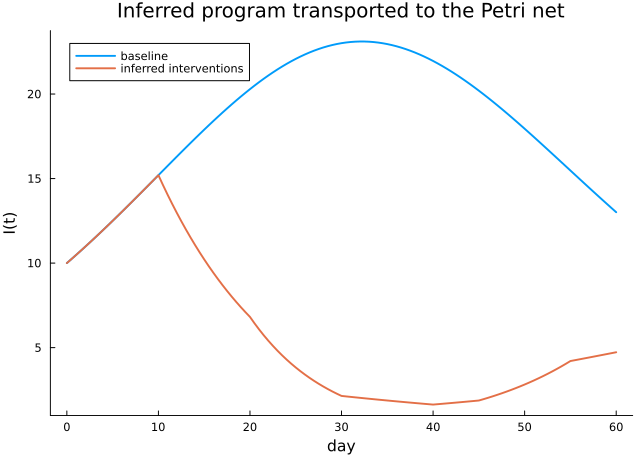

```julia
u0 = LVector(S=990.0, I=10.0, R=0.0)
p0 = LVector(inf=0.30 / sum(u0), rec=0.25)
tspan = (0.0, 60.0)
with = simulate(model, program; u0, p0, tspan, alg=Tsit5(), saveat=0.5)
without = simulate(model, Program(model); u0, p0, tspan, alg=Tsit5(), saveat=0.5)

plot(without.t, without[2, :]; label="baseline", xlabel="day", ylabel="I(t)",
     title="Inferred program transported to the Petri net")
plot!(with.t, with[2, :]; label="inferred interventions")
```

## What the category theory bought

Applying the inferred program to the baseline returns the observed schedule on the grid (`infer_putget`): `infer` is the `get` of a lens whose `put` is `apply`. Renaming targets is functorial and, being injective here, preserves conflict-freeness (`pushforward_comp`, `conflictFree_pushforward_of_injOn`), so the program that explains the fit is, without further checking, a valid program on the new model. The Lean development proves the per-cell form of `infer_putget`; the run-merging done here is an implementation refinement that the property tests cover.